# [**About me**](https://kelferdm.github.io/about-me) | [**Portfolio**](https://kelferdm.github.io/projects) | [**Resume**](https://kelferdm.github.io/resume/Resume_KM_2023.pdf)

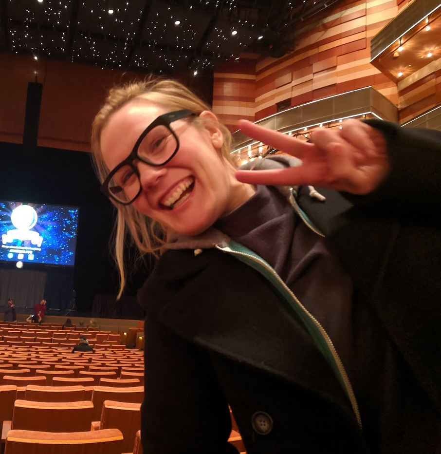

#### **My greatest love is my pack of rescue dogs. My second greatest love is turning data into useful insights and actions.**

#### **In my current position as a Performance Marketing Analyst, I prepare weekly auditing reports to review all data that is received via our lead generation channels. After the data has been audited and any discrepancies corrected, I create dashboards that provide a daily reference to track our lead information over time. I also use other external data sources to create statistical analyses and predictions to assist team members in streamlining their marketing campaigns to better reach their audiences.**

#### **As a Data Operations Consultant for Filevine, I routinely worked with stakeholders to analyze, clean, transform, and organize data using Excel and R in order to migrate their data into their Filevine or Lead Docket environment. Clients and I were in constant collaboration to not only find the correct data, but also to correct and organize their data into an easily readable and usable format.**

#### **In my previous employment as a data analyst at Utah Valley University, and employment as a teacher and researcher, I have been required to utilize technology resources including university databases, Oracle, SQL, R, and digital libraries to facilitate organizational research. I assisted various university departments in using Oracle, SQL, Excel, and Tableau to answer questions about department success, visualize the learning outcomes of a variety of courses and degrees, and analyze student performance. I also used R to statistically locate and visualize predictors of academic success at Utah Valley University as well as created a Shiny application to make the University College data entry process more efficient.**

#### **With my combined 4 years of experience in data organization and data analysis roles at Filevine and the University College at Utah Valley University, I acquired a background in problem solving, employee training, and collaborative group work as well as solo projects.**

___

### Contact Info:

Email: kellylmoney@protonmail.com

Linkedin: kellymoney